# Prediction Assignment

Isis Ibarra

17/11/2018

## 1. Overview

People regularly quantify how much of an excercise they do, but rarely measure their performance. In this investigation, data from accelerometers on the belt, forearm, arm, and dumbell of 6 participants will be used to predict the manner of the subject. Random forest, decision tree and generalized boosted model will be the methods implemented to determine the best predicion. R programming will be the major tool used in the project.

## 2. Data preparation

The data for this project is taken from the Human Activity Recognition project by Groupware@LES. For more information, please visit their [website](http://web.archive.org/web/20161224072740/http:/groupware.les.inf.puc-rio.br/har).

As the first step in this investigation, data preparation is needed. The following code is used to load the corresponding libraries.

```r
library(knitr)
library(caret)
library(rpart)
library(rpart.plot)
library(rattle)
library(randomForest)
library(corrplot)
library(e1071)
```

The next step is loading the dataset from the URL provided, and store the information into the `training` and `testing` variables.

```r
trainURL <- "https://d396qusza40orc.cloudfront.net/predmachlearn/pml-training.csv"
testURL <- "https://d396qusza40orc.cloudfront.net/predmachlearn/pml-testing.csv"
trainFile <- "pml-traininig.csv"
testFile <- "pml-testing.csv"

if(!file.exists(trainFile))
{
  download.file(trainURL, destfile = trainFile)
}
if(!file.exists(testFile))
{
  download.file(testURL, destfile = testFile)
}

training <- read.csv(trainFile)
testing <- read.csv(testFile)
```

In order to have a better predictive model, `training` dataset is partitioned into 2 subsets:  
* `trainSet`: consists of 70% of the dataset; will be used for the modeling process  
* `validationSet`: consists of 30% of the dataset; will be used for cross validation

```r
trainingPartition <- createDataPartition(training$classe, p = 0.7, list = FALSE)
trainSet <- training[trainingPartition, ]
validationSet <- training[-trainingPartition, ]
```

To ensure classification rules can be applied to the dataset, data cleansing must be done. The following considerations will be entered:  
1. Remove the constant and almost constant variables accross the sample  
2. Remove variables composed of at least 95% of missing values or empty strings  
3. Remove identification variables, such as time and user information

```r
# Remove constant and almost constant varibales across the sample
NZV <- nearZeroVar(trainSet)
trainSet <- trainSet[, -NZV]
validationSet <- validationSet[, -NZV]
# Remove variables with mostly missing values
na <- sapply(trainSet, function(x) mean(is.na(x))) > 0.95
trainSet <- trainSet[, na == FALSE]
validationSet <- validationSet[, na == FALSE]
# Remove identification variables
trainSet <- trainSet[, -(1:5)]
validationSet  <- validationSet[, -(1:5)]
```

After this cleansing process, there are 53 variables suited for analysis.

## 3. Exploratory analysis

To get a better insight of the relationship between the variables, a correlation analyisis will be done.

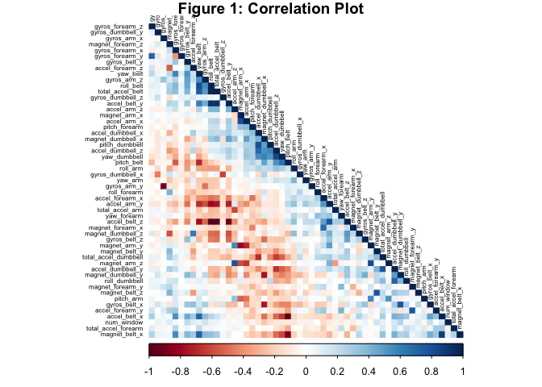

```r
plotCorrelation <- cor(trainSet[, -54])
corrplot(plotCorrelation, method = "color", order = "AOE", type = "lower", tl.cex = 0.5, tl.col = rgb(0, 0, 0), title = "Figure 1: Correlation Plot", mar=c(0,0,1,0))
```

In Figure 1: Correlation Plot, highly possitively correlated values are painted in dark blue, while negatively are colored dark red.

## 4. Predictive models

Now, three popular methods will be applied to model the regressions in the training dataset. A confusion matrix is plotted at the end of each analysis to better visualize the accuracy of the models.

### 4.1 Random forest

```r
# Set seed for reproducibility
set.seed(1234)
# Create random forest model
controlRF <- trainControl(method = "cv", number = 3, verboseIter = FALSE)
modelRF <- train(classe ~ ., data = trainSet, method = "rf", trControl = controlRF)
modelRF$finalModel
```

```
##
## Call:
##  randomForest(x = x, y = y, mtry = param$mtry)
##                Type of random forest: classification
##                      Number of trees: 500
## No. of variables tried at each split: 27
##
##         OOB estimate of  error rate: 0.27%
## Confusion matrix:
##      A    B    C    D    E class.error
## A 3906    0    0    0    0 0.000000000
## B    9 2644    4    1    0 0.005267118
## C    0    6 2390    0    0 0.002504174
## D    0    0   12 2239    1 0.005772647
## E    0    0    0    4 2521 0.001584158
```

```r
# Predict using the test dataset
predictRF <- predict(modelRF, newdata = validationSet)
confusionMatrixRF <- confusionMatrix(predictRF, validationSet$classe)
confusionMatrixRF
```

```
## Confusion Matrix and Statistics
##
##           Reference
## Prediction    A    B    C    D    E
##          A 1673    1    0    0    0
##          B    0 1138    2    0    0
##          C    0    0 1024    3    0
##          D    0    0    0  961    1
##          E    1    0    0    0 1081
##
## Overall Statistics
##
##                Accuracy : 0.9986
##                  95% CI : (0.9973, 0.9994)
##     No Information Rate : 0.2845
##     P-Value [Acc > NIR] : < 2.2e-16
##
##                   Kappa : 0.9983
##  Mcnemar's Test P-Value : NA
##
## Statistics by Class:
##
##                      Class: A Class: B Class: C Class: D Class: E
## Sensitivity            0.9994   0.9991   0.9981   0.9969   0.9991
## Specificity            0.9998   0.9996   0.9994   0.9998   0.9998
## Pos Pred Value         0.9994   0.9982   0.9971   0.9990   0.9991
## Neg Pred Value         0.9998   0.9998   0.9996   0.9994   0.9998
## Prevalence             0.2845   0.1935   0.1743   0.1638   0.1839
## Detection Rate         0.2843   0.1934   0.1740   0.1633   0.1837
## Detection Prevalence   0.2845   0.1937   0.1745   0.1635   0.1839
## Balanced Accuracy      0.9996   0.9994   0.9987   0.9983   0.9994
```

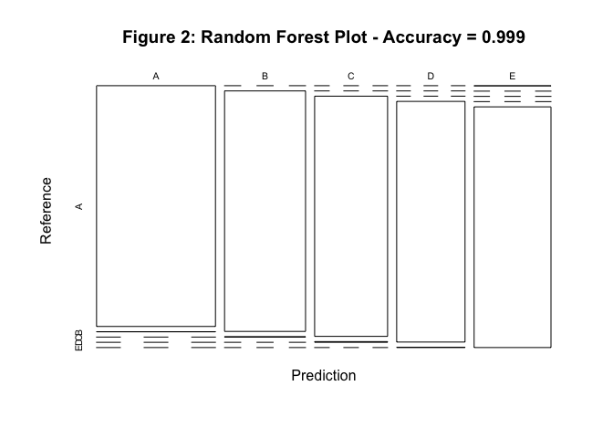

```r
# Plot results
plot(confusionMatrixRF$table, col = confusionMatrixRF$byClass,
    main = paste("Figure 2: Random Forest Plot - Accuracy =",
                 round(confusionMatrixRF$overall['Accuracy'], 3)))
```

### 4.2 Decision tree

```r
# Set seed for reproducibility
set.seed(1234)
# Create decision tree model
modelDT <- rpart(classe ~ ., data = trainSet, method = "class")
# Predict using the test dataset
predictDT <- predict(modelDT, newdata = validationSet, type = "class")
confusionMatrixDT <- confusionMatrix(predictDT, validationSet$classe)
confusionMatrixDT
```

```
## Confusion Matrix and Statistics
##
##           Reference
## Prediction    A    B    C    D    E
##          A 1506  271   38  109   66
##          B   32  609   45   28   80
##          C   26   80  866  150   85
##          D   88  148   69  639  139
##          E   22   31    8   38  712
##
## Overall Statistics
##
##                Accuracy : 0.7361
##                  95% CI : (0.7246, 0.7473)
##     No Information Rate : 0.2845
##     P-Value [Acc > NIR] : < 2.2e-16
##
##                   Kappa : 0.6645
##  Mcnemar's Test P-Value : < 2.2e-16
##
## Statistics by Class:
##
##                      Class: A Class: B Class: C Class: D Class: E
## Sensitivity            0.8996   0.5347   0.8441   0.6629   0.6580
## Specificity            0.8851   0.9610   0.9298   0.9098   0.9794
## Pos Pred Value         0.7568   0.7670   0.7175   0.5900   0.8779
## Neg Pred Value         0.9569   0.8959   0.9658   0.9323   0.9271
## Prevalence             0.2845   0.1935   0.1743   0.1638   0.1839
## Detection Rate         0.2559   0.1035   0.1472   0.1086   0.1210
## Detection Prevalence   0.3381   0.1349   0.2051   0.1840   0.1378
## Balanced Accuracy      0.8924   0.7478   0.8869   0.7863   0.8187
```

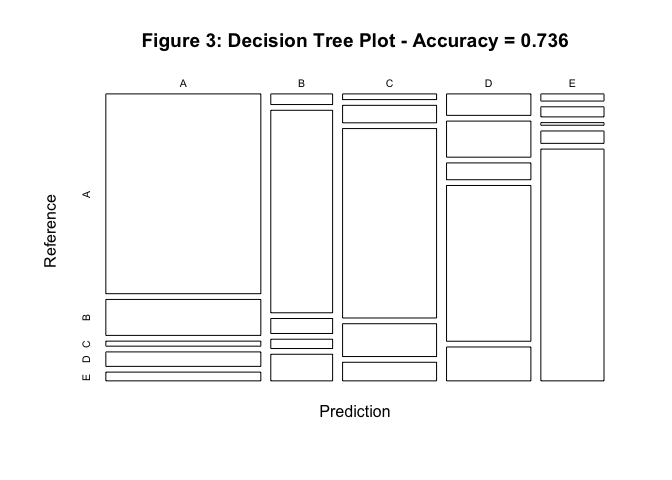

```r
# Plot results
plot(confusionMatrixDT$table, col = confusionMatrixDT$byClass,
    main = paste("Figure 3: Decision Tree Plot - Accuracy =",
                 round(confusionMatrixDT$overall['Accuracy'], 3)))
```

### 4.3 Generalized boosted model

```r
# Set seed for reproducibility
set.seed(1234)
# Create decision tree model
controlGBM <- trainControl(method = "repeatedcv", number = 5, repeats = 1)
modelGBM <- train(classe ~ ., data = trainSet, method = "gbm", trControl = controlGBM, verbose = FALSE)
modelGBM$finalModel
```

```
## A gradient boosted model with multinomial loss function.
## 150 iterations were performed.
## There were 53 predictors of which 43 had non-zero influence.
```

```r
# Predict using the test dataset
predictGBM <- predict(modelGBM, newdata = validationSet)
confusionMatrixGBM <- confusionMatrix(predictGBM, validationSet$classe)
confusionMatrixGBM
```

```
## Confusion Matrix and Statistics
##
##           Reference
## Prediction    A    B    C    D    E
##          A 1671   12    0    0    0
##          B    3 1118   16    3    2
##          C    0    8 1007   16    1
##          D    0    1    3  943    7
##          E    0    0    0    2 1072
##
## Overall Statistics
##
##                Accuracy : 0.9874
##                  95% CI : (0.9842, 0.9901)
##     No Information Rate : 0.2845
##     P-Value [Acc > NIR] : < 2.2e-16
##
##                   Kappa : 0.9841
##  Mcnemar's Test P-Value : NA
##
## Statistics by Class:
##
##                      Class: A Class: B Class: C Class: D Class: E
## Sensitivity            0.9982   0.9816   0.9815   0.9782   0.9908
## Specificity            0.9972   0.9949   0.9949   0.9978   0.9996
## Pos Pred Value         0.9929   0.9790   0.9758   0.9885   0.9981
## Neg Pred Value         0.9993   0.9956   0.9961   0.9957   0.9979
## Prevalence             0.2845   0.1935   0.1743   0.1638   0.1839
## Detection Rate         0.2839   0.1900   0.1711   0.1602   0.1822
## Detection Prevalence   0.2860   0.1941   0.1754   0.1621   0.1825
## Balanced Accuracy      0.9977   0.9883   0.9882   0.9880   0.9952
```

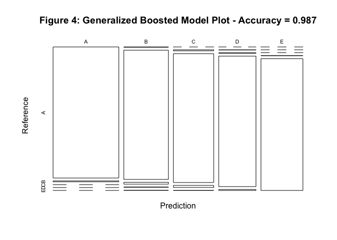

```r
# Plot results
plot(confusionMatrixGBM$table, col = confusionMatrixGBM$byClass,
    main = paste("Figure 4: Generalized Boosted Model Plot - Accuracy =",
                 round(confusionMatrixGBM$overall['Accuracy'], 3)))
```

## 5. Applying selected model to test data

```r
predict <- predict(modelRF, newdata = testing)
predict
```

```
##  [1] B A B A A E D B A A B C B A E E A B B B
## Levels: A B C D E
```